# Component Developmental Sequence Analysis

Bryan Terlizzi

# Data Description:

### Created Variables across the 4 skills:

1. Mode for each DS component.
2. Component Profile for each of 5 trial.
3. Component Profile Mode for each of 5 timepoints.

# Analysis.

## Frequency of Each Component for each timepoint

### Throwing.

Step.

| Cohort | Timepoint | 1 | 2 | 3 |
| --- | --- | --- | --- | --- |
| C1 | T1 | 0.5053763 | 0.2043011 | 0.2903226 |
| C1 | T2 | 0.3805310 | 0.1858407 | 0.4336283 |
| C1 | T3 | 0.3134328 | 0.2089552 | 0.4776119 |
| C1 | T4 | 0.4126984 | 0.1269841 | 0.4603175 |
| C1 | T5 | 0.3823529 | 0.1470588 | 0.4705882 |
| C2 | T1 | 0.4969697 | 0.1454545 | 0.3575758 |
| C2 | T2 | 0.5029940 | 0.1317365 | 0.3652695 |
| C2 | T3 | 0.5029940 | 0.1317365 | 0.3652695 |

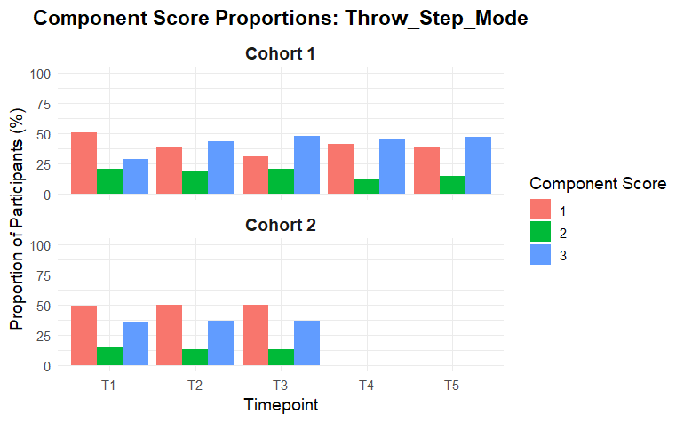

Trunk.

| Cohort | Timepoint | 1 | 2 |
| --- | --- | --- | --- |
| C1 | T1 | 0.4408602 | 0.5591398 |
| C1 | T2 | 0.2743363 | 0.7256637 |
| C1 | T3 | 0.2537313 | 0.7462687 |
| C1 | T4 | 0.2698413 | 0.7301587 |
| C1 | T5 | 0.1617647 | 0.8382353 |
| C2 | T1 | 0.3696970 | 0.6303030 |
| C2 | T2 | 0.2574850 | 0.7425150 |
| C2 | T3 | 0.2574850 | 0.7425150 |

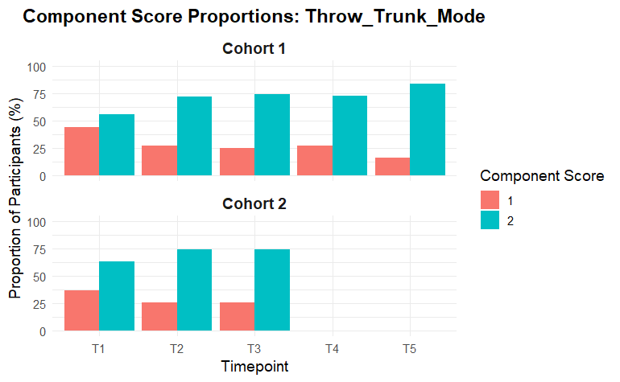

Humerus.

| Cohort | Timepoint | 1 | 2 | 3 |
| --- | --- | --- | --- | --- |
| C1 | T1 | 0.7204301 | 0.2580645 | 0.021505376 |
| C1 | T2 | 0.6814159 | 0.2831858 | 0.035398230 |
| C1 | T3 | 0.5671642 | 0.3731343 | 0.059701493 |
| C1 | T4 | 0.5873016 | 0.3650794 | 0.047619048 |
| C1 | T5 | 0.4411765 | 0.4852941 | 0.073529412 |
| C2 | T1 | 0.6787879 | 0.2909091 | 0.030303030 |
| C2 | T2 | 0.5628743 | 0.4311377 | 0.005988024 |
| C2 | T3 | 0.5628743 | 0.4311377 | 0.005988024 |

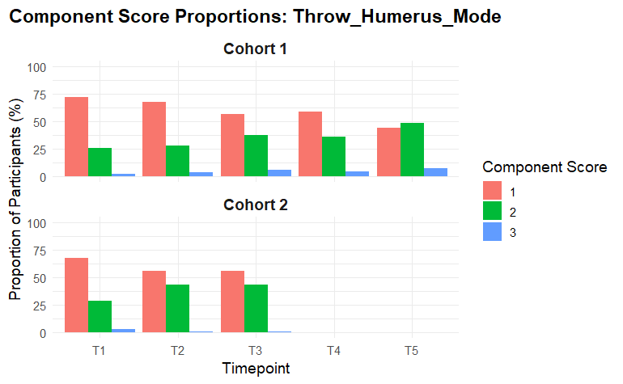

Forearm.

| Cohort | Timepoint | 1 | 2 | 3 |
| --- | --- | --- | --- | --- |
| C1 | T1 | 0.6559140 | 0.3440860 | 0.000000000 |
| C1 | T2 | 0.6106195 | 0.3805310 | 0.008849558 |
| C1 | T3 | 0.4179104 | 0.5671642 | 0.014925373 |
| C1 | T4 | 0.4444444 | 0.5555556 | 0.000000000 |
| C1 | T5 | 0.2941176 | 0.6911765 | 0.014705882 |
| C2 | T1 | 0.5272727 | 0.4666667 | 0.006060606 |
| C2 | T2 | 0.4730539 | 0.5269461 | 0.000000000 |
| C2 | T3 | 0.4730539 | 0.5269461 | 0.000000000 |

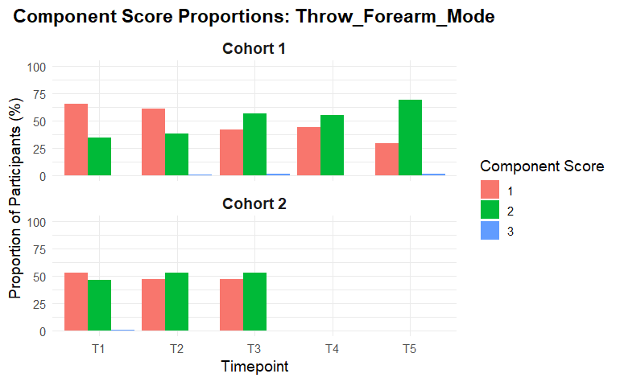

### Kicking

Approach.

| Cohort | Timepoint | 1 | 2 | 3 |
| --- | --- | --- | --- | --- |
| C1 | T1 | 0.04123711 | 0.9484536 | 0.010309278 |
| C1 | T2 | 0.02631579 | 0.9035088 | 0.070175439 |
| C1 | T3 | 0.00000000 | 0.8507463 | 0.149253731 |
| C1 | T4 | 0.00000000 | 1.0000000 | 0.000000000 |
| C1 | T5 | 0.00000000 | 0.6617647 | 0.338235294 |
| C2 | T1 | 0.01764706 | 0.9764706 | 0.005882353 |
| C2 | T2 | 0.01204819 | 0.9578313 | 0.030120482 |
| C2 | T3 | 0.00000000 | 1.0000000 | 0.000000000 |

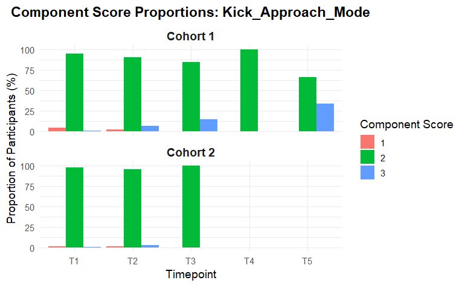

Support Location.

| Cohort | Timepoint | 2 | 3 | 1 |
| --- | --- | --- | --- | --- |
| C1 | T1 | 0.2886598 | 0.7113402 | 0.000000000 |
| C1 | T2 | 0.1842105 | 0.8070175 | 0.008771930 |
| C1 | T3 | 0.3582090 | 0.6417910 | 0.000000000 |
| C1 | T4 | 0.2857143 | 0.7142857 | 0.000000000 |
| C1 | T5 | 0.3088235 | 0.6911765 | 0.000000000 |
| C2 | T1 | 0.2470588 | 0.7470588 | 0.005882353 |
| C2 | T2 | 0.2409639 | 0.7530120 | 0.006024096 |
| C2 | T3 | 0.2307692 | 0.7692308 | 0.000000000 |

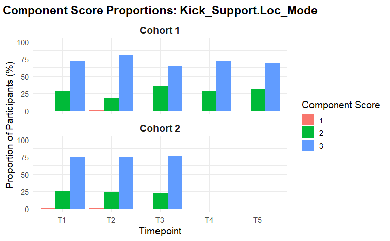

Knee Action.

| Cohort | Timepoint | 2 | 3 | 1 |
| --- | --- | --- | --- | --- |
| C1 | T1 | 0.9278351 | 0.07216495 | 0.000000000 |
| C1 | T2 | 0.9561404 | 0.02631579 | 0.017543860 |
| C1 | T3 | 0.9850746 | 0.01492537 | 0.000000000 |
| C1 | T4 | 0.9523810 | 0.04761905 | 0.000000000 |
| C1 | T5 | 0.9411765 | 0.05882353 | 0.000000000 |
| C2 | T1 | 0.9705882 | 0.01176471 | 0.017647059 |
| C2 | T2 | 0.9819277 | 0.01204819 | 0.006024096 |
| C2 | T3 | 0.9230769 | 0.07692308 | 0.000000000 |

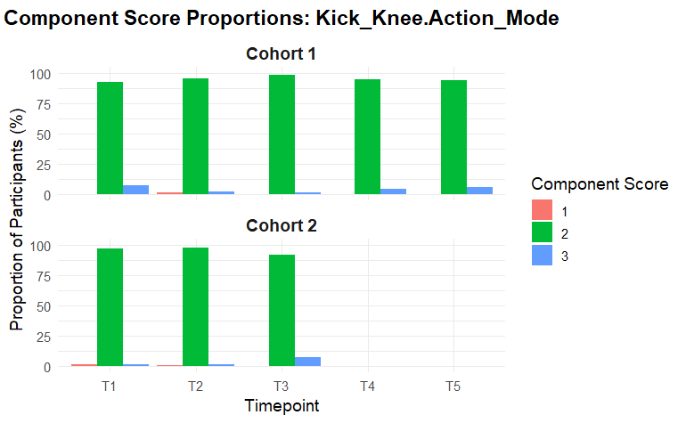

Trunk Action.

| Cohort | Timepoint | 1 | 2 |
| --- | --- | --- | --- |
| C1 | T1 | 0.9587629 | 0.04123711 |
| C1 | T2 | 0.9122807 | 0.08771930 |
| C1 | T3 | 0.8656716 | 0.13432836 |
| C1 | T4 | 1.0000000 | 0.00000000 |
| C1 | T5 | 0.6617647 | 0.33823529 |
| C2 | T1 | 0.9411765 | 0.05882353 |
| C2 | T2 | 0.9156627 | 0.08433735 |
| C2 | T3 | 1.0000000 | 0.00000000 |

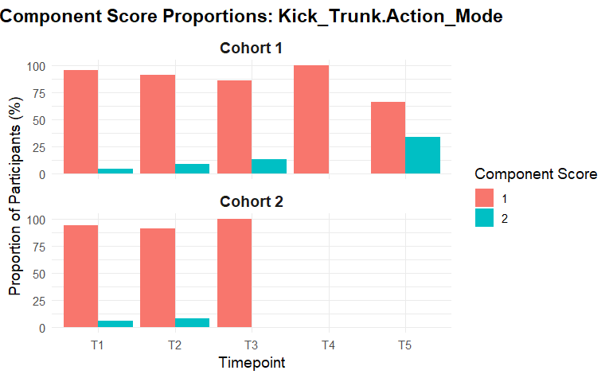

Arm Action.

| Cohort | Timepoint | 1 | 2 | 3 |
| --- | --- | --- | --- | --- |
| C1 | T1 | 0.030927835 | 0.9587629 | 0.01030928 |
| C1 | T2 | 0.000000000 | 1.0000000 | 0.00000000 |
| C1 | T3 | 0.000000000 | 1.0000000 | 0.00000000 |
| C1 | T4 | 0.000000000 | 1.0000000 | 0.00000000 |
| C1 | T5 | 0.000000000 | 1.0000000 | 0.00000000 |
| C2 | T1 | 0.017647059 | 0.9823529 | 0.00000000 |
| C2 | T2 | 0.006024096 | 0.9939759 | 0.00000000 |
| C2 | T3 | 0.000000000 | 1.0000000 | 0.00000000 |

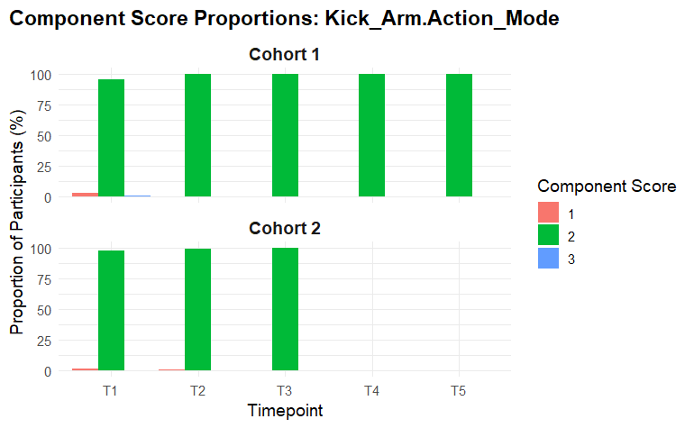

Follow Through.

| Cohort | Timepoint | 1 | 2 | 3 |
| --- | --- | --- | --- | --- |
| C1 | T1 | 0.123711340 | 0.6597938 | 0.2164948 |
| C1 | T2 | 0.070175439 | 0.6315789 | 0.2982456 |
| C1 | T3 | 0.044776119 | 0.6716418 | 0.2835821 |
| C1 | T4 | 0.000000000 | 0.3968254 | 0.6031746 |
| C1 | T5 | 0.014705882 | 0.8529412 | 0.1323529 |
| C2 | T1 | 0.073619632 | 0.8036810 | 0.1226994 |
| C2 | T2 | 0.036144578 | 0.7349398 | 0.2289157 |
| C2 | T3 | 0.008547009 | 0.7094017 | 0.2820513 |

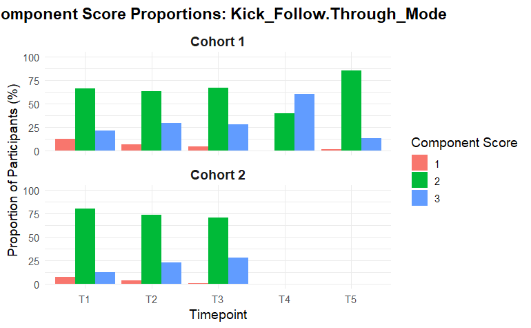

### Hopping.

Arm Action.

| Cohort | Timepoint | 1 | 2 | 3 | 4 | 5 |
| --- | --- | --- | --- | --- | --- | --- |
| C1 | T1 | 0.45054945 | 0.4945055 | 0.05494505 | 0.000000000 | 0.00000000 |
| C1 | T2 | 0.27777778 | 0.5462963 | 0.10185185 | 0.074074074 | 0.00000000 |
| C1 | T3 | 0.41935484 | 0.4677419 | 0.01612903 | 0.096774194 | 0.00000000 |
| C1 | T4 | 0.13114754 | 0.6721311 | 0.06557377 | 0.114754098 | 0.01639344 |
| C1 | T5 | 0.04477612 | 0.6865672 | 0.05970149 | 0.194029851 | 0.01492537 |
| C2 | T1 | 0.56296296 | 0.3333333 | 0.09629630 | 0.007407407 | 0.00000000 |
| C2 | T2 | 0.41059603 | 0.4370861 | 0.06622517 | 0.072847682 | 0.01324503 |
| C2 | T3 | 0.33620690 | 0.3793103 | 0.15517241 | 0.103448276 | 0.02586207 |

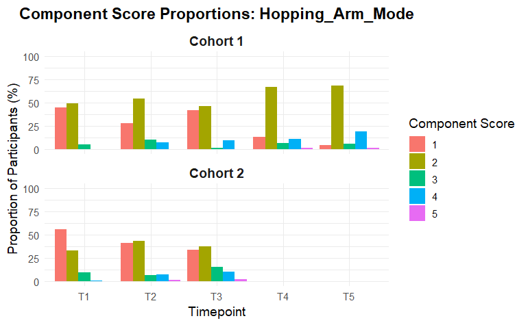

Leg Action.

| Cohort | Timepoint | 1 | 2 | 3 | 4 |
| --- | --- | --- | --- | --- | --- |
| C1 | T1 | 0.26373626 | 0.6703297 | 0.06593407 | 0.00000000 |
| C1 | T2 | 0.10185185 | 0.6666667 | 0.21296296 | 0.01851852 |
| C1 | T3 | 0.08064516 | 0.7096774 | 0.20967742 | 0.00000000 |
| C1 | T4 | 0.06557377 | 0.6393443 | 0.22950820 | 0.06557377 |
| C1 | T5 | 0.02985075 | 0.6417910 | 0.26865672 | 0.05970149 |
| C2 | T1 | 0.30370370 | 0.5925926 | 0.10370370 | 0.00000000 |
| C2 | T2 | 0.20529801 | 0.5894040 | 0.17218543 | 0.03311258 |
| C2 | T3 | 0.10344828 | 0.6551724 | 0.18965517 | 0.05172414 |

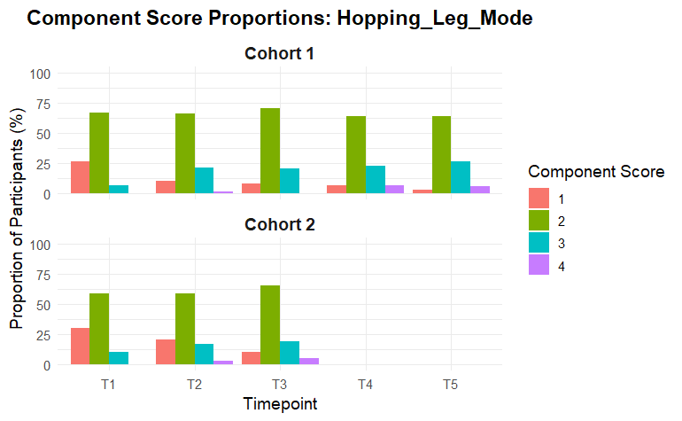

### Jumping.

Takeoff - Arm.

| Cohort | Timepoint | 1 | 2 | 3 | 4 | x |
| --- | --- | --- | --- | --- | --- | --- |
| C1 | T1 | 0.3589744 | 0.5384615 | 0.07692308 | 0.025641026 | 0.00000000 |
| C1 | T2 | 0.1858407 | 0.4070796 | 0.39823009 | 0.008849558 | 0.00000000 |
| C1 | T3 | 0.2238806 | 0.2686567 | 0.46268657 | 0.044776119 | 0.00000000 |
| C1 | T4 | 0.2258065 | 0.2741935 | 0.45161290 | 0.048387097 | 0.00000000 |
| C1 | T5 | 0.2089552 | 0.1940299 | 0.55223881 | 0.044776119 | 0.00000000 |
| C2 | T1 | 0.3395062 | 0.5555556 | 0.08641975 | 0.012345679 | 0.00617284 |
| C2 | T2 | 0.2261905 | 0.3333333 | 0.41666667 | 0.023809524 | 0.00000000 |
| C2 | T3 | 0.1367521 | 0.3589744 | 0.47863248 | 0.025641026 | 0.00000000 |

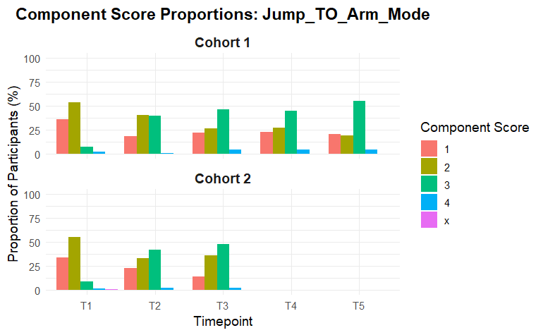

Takeoff - Leg.

| Cohort | Timepoint | 1 | 2 | 3 | 4 | x |
| --- | --- | --- | --- | --- | --- | --- |
| C1 | T1 | 0.02564103 | 0.02564103 | 0.3846154 | 0.5641026 | 0.00000000 |
| C1 | T2 | 0.01769912 | 0.00000000 | 0.1504425 | 0.7610619 | 0.07079646 |
| C1 | T3 | 0.01492537 | 0.00000000 | 0.4477612 | 0.5373134 | 0.00000000 |
| C1 | T4 | 0.01612903 | 0.01612903 | 0.3387097 | 0.6290323 | 0.00000000 |
| C1 | T5 | 0.02985075 | 0.00000000 | 0.2089552 | 0.7611940 | 0.00000000 |
| C2 | T1 | 0.13580247 | 0.00000000 | 0.5864198 | 0.2654321 | 0.01234568 |
| C2 | T2 | 0.05952381 | 0.00000000 | 0.3154762 | 0.6130952 | 0.01190476 |
| C2 | T3 | 0.06837607 | 0.00000000 | 0.1623932 | 0.7692308 | 0.00000000 |

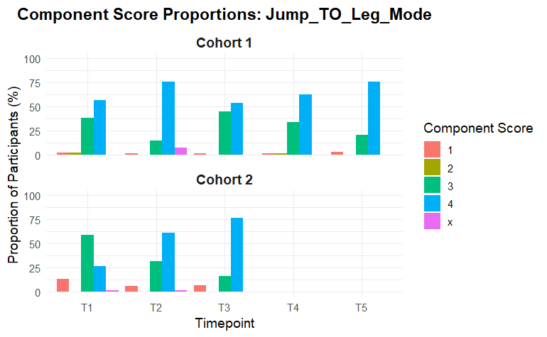

Landing - Arm.

| Cohort | Timepoint | 1 | 2 | 3 | 4 |
| --- | --- | --- | --- | --- | --- |
| C1 | T1 | 0.1794872 | 0.7435897 | 0.02564103 | 0.05128205 |
| C1 | T2 | 0.1327434 | 0.7964602 | 0.05309735 | 0.01769912 |
| C1 | T3 | 0.1641791 | 0.7761194 | 0.05970149 | 0.00000000 |
| C1 | T4 | 0.1746032 | 0.7301587 | 0.03174603 | 0.06349206 |
| C1 | T5 | 0.1194030 | 0.6268657 | 0.14925373 | 0.10447761 |
| C2 | T1 | 0.4629630 | 0.4938272 | 0.03086420 | 0.01234568 |
| C2 | T2 | 0.2738095 | 0.6369048 | 0.04761905 | 0.04166667 |
| C2 | T3 | 0.1196581 | 0.7777778 | 0.03418803 | 0.06837607 |

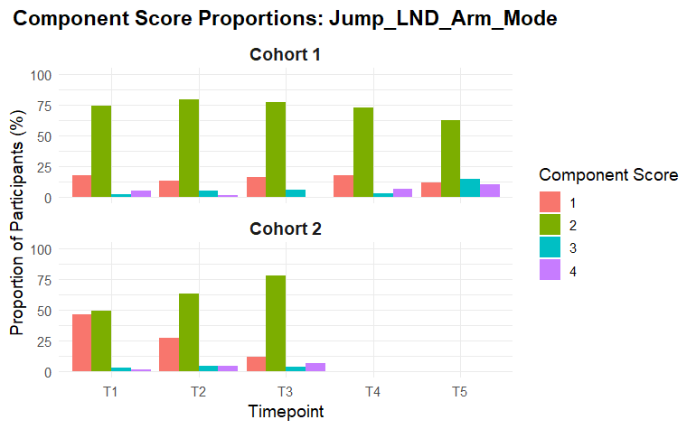

Landing - Foot.

| Cohort | Timepoint | 1 | 2 | 3 |
| --- | --- | --- | --- | --- |
| C1 | T1 | 0.12820513 | 0.6153846 | 0.2564103 |
| C1 | T2 | 0.09734513 | 0.4159292 | 0.4867257 |
| C1 | T3 | 0.14925373 | 0.2835821 | 0.5671642 |
| C1 | T4 | 0.09523810 | 0.2380952 | 0.6666667 |
| C1 | T5 | 0.11940299 | 0.1791045 | 0.7014925 |
| C2 | T1 | 0.25308642 | 0.4629630 | 0.2839506 |
| C2 | T2 | 0.14880952 | 0.2857143 | 0.5654762 |
| C2 | T3 | 0.11965812 | 0.3162393 | 0.5641026 |

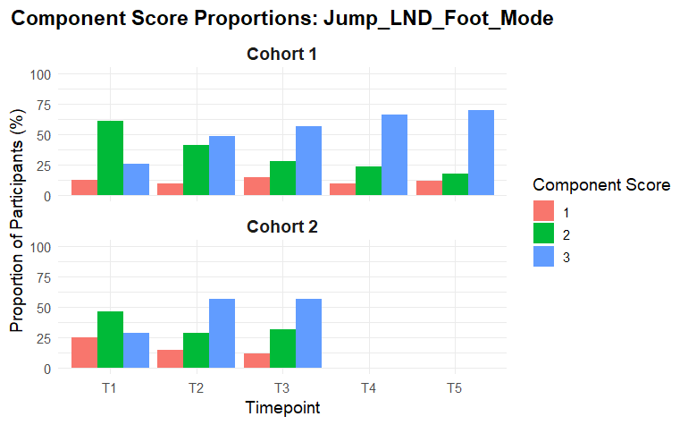

Landing - Shank.

| Cohort | Timepoint | 1 | 2 |
| --- | --- | --- | --- |
| C1 | T1 | 0.48717949 | 0.5128205 |
| C1 | T2 | 0.23008850 | 0.7699115 |
| C1 | T3 | 0.17910448 | 0.8208955 |
| C1 | T4 | 0.04761905 | 0.9523810 |
| C1 | T5 | 0.10447761 | 0.8955224 |
| C2 | T1 | 0.34567901 | 0.6543210 |
| C2 | T2 | 0.16666667 | 0.8333333 |
| C2 | T3 | 0.07692308 | 0.9230769 |

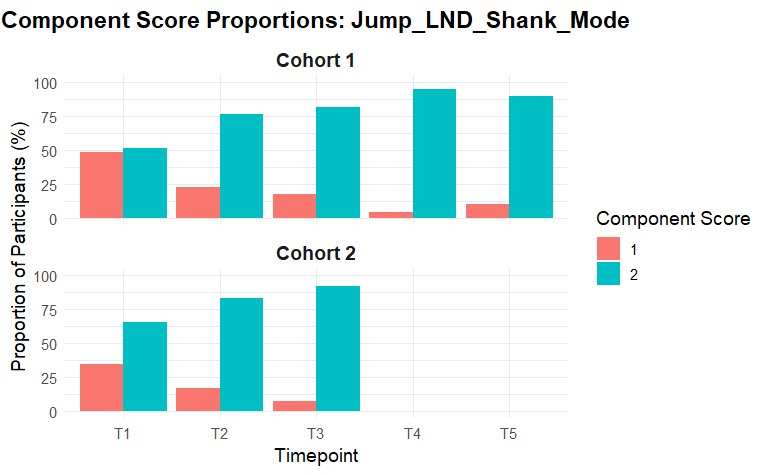

## Frequency and Proportion of Profile Modes at different timepoints

Try at a Figure to illustrate

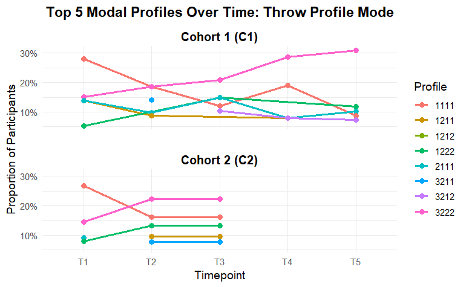

**Note:** Throwing profile components are ordered as: Step, Trunk, Humerus, Forearm.

| Cohort | Timepoint | 1111 | 3222 | 1211 | 2111 | 1222 | 3211 | 3212 | 1212 |
| --- | --- | --- | --- | --- | --- | --- | --- | --- | --- |
| C1 | T1 | 0.27956989 | 0.1505376 | 0.13978495 | 0.13978495 | 0.05376344 | 0.00000000 | 0.00000000 | 0.00000000 |
| C1 | T2 | 0.18584071 | 0.1858407 | 0.08849558 | 0.09734513 | 0.00000000 | 0.14159292 | 0.00000000 | 0.00000000 |
| C1 | T3 | 0.11940299 | 0.2089552 | 0.00000000 | 0.14925373 | 0.14925373 | 0.00000000 | 0.10447761 | 0.00000000 |
| C1 | T4 | 0.19047619 | 0.2857143 | 0.07936508 | 0.07936508 | 0.00000000 | 0.00000000 | 0.07936508 | 0.00000000 |
| C1 | T5 | 0.08823529 | 0.3088235 | 0.00000000 | 0.10294118 | 0.11764706 | 0.00000000 | 0.07352941 | 0.00000000 |
| C2 | T1 | 0.26666667 | 0.1454545 | 0.00000000 | 0.09090909 | 0.07878788 | 0.00000000 | 0.00000000 | 0.07878788 |
| C2 | T2 | 0.16167665 | 0.2215569 | 0.09580838 | 0.00000000 | 0.13173653 | 0.07784431 | 0.00000000 | 0.00000000 |
| C2 | T3 | 0.16167665 | 0.2215569 | 0.09580838 | 0.00000000 | 0.13173653 | 0.07784431 | 0.00000000 | 0.00000000 |

**Note:** Throwing profile components are ordered as: Step, Trunk, Humerus, Forearm.

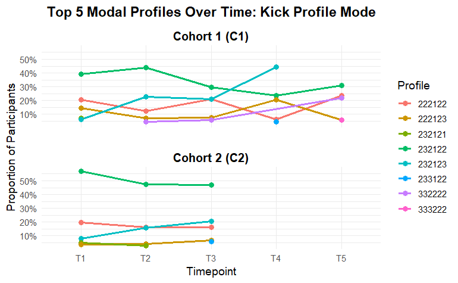

**Note:** Kicking profile components are ordered as: Approach, Support Leg, Knee Action, Trunk Action, Arm Action, Follow Through.

| Cohort | Timepoint | 232122 | 222122 | 222123 | 232121 | 232123 | 332222 | 233122 | 333222 |
| --- | --- | --- | --- | --- | --- | --- | --- | --- | --- |
| C1 | T1 | 0.3917526 | 0.20618557 | 0.14432990 | 0.07216495 | 0.06185567 | 0.00000000 | 0.00000000 | 0.00000000 |
| C1 | T2 | 0.4385965 | 0.12280702 | 0.07017544 | 0.00000000 | 0.22807018 | 0.04385965 | 0.00000000 | 0.00000000 |
| C1 | T3 | 0.2985075 | 0.20895522 | 0.07462687 | 0.00000000 | 0.20895522 | 0.05970149 | 0.00000000 | 0.00000000 |
| C1 | T4 | 0.2380952 | 0.06349206 | 0.20634921 | 0.00000000 | 0.44444444 | 0.00000000 | 0.04761905 | 0.00000000 |
| C1 | T5 | 0.3088235 | 0.23529412 | 0.05882353 | 0.00000000 | 0.00000000 | 0.22058824 | 0.00000000 | 0.05882353 |
| C2 | T1 | 0.5705521 | 0.19631902 | 0.03680982 | 0.04907975 | 0.07975460 | 0.00000000 | 0.00000000 | 0.00000000 |
| C2 | T2 | 0.4759036 | 0.16265060 | 0.04216867 | 0.03012048 | 0.15662651 | 0.00000000 | 0.00000000 | 0.00000000 |
| C2 | T3 | 0.4700855 | 0.16239316 | 0.06837607 | 0.00000000 | 0.20512821 | 0.00000000 | 0.05982906 | 0.00000000 |

**Note:** Kicking profile components are ordered as: Approach, Support Leg, Knee Action, Trunk Action, Arm Action, Follow Through.

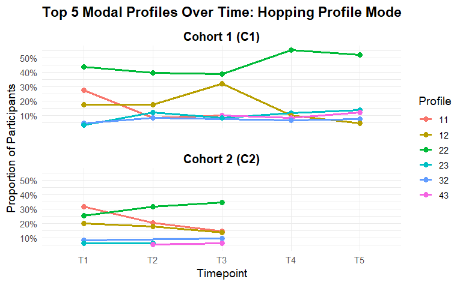

**Note:** Hopping profile components are ordered as: Arm, Leg.

| Cohort | Timepoint | 22 | 11 | 12 | 32 | 23 | 43 |
| --- | --- | --- | --- | --- | --- | --- | --- |
| C1 | T1 | 0.4395604 | 0.27472527 | 0.17582418 | 0.04395604 | 0.03296703 | 0.00000000 |
| C1 | T2 | 0.3981481 | 0.08333333 | 0.17592593 | 0.08333333 | 0.12037037 | 0.00000000 |
| C1 | T3 | 0.3870968 | 0.09677419 | 0.32258065 | 0.00000000 | 0.08064516 | 0.09677419 |
| C1 | T4 | 0.5573770 | 0.00000000 | 0.09836066 | 0.06557377 | 0.11475410 | 0.08196721 |
| C1 | T5 | 0.5223881 | 0.00000000 | 0.04477612 | 0.07462687 | 0.13432836 | 0.11940299 |
| C2 | T1 | 0.2518519 | 0.31851852 | 0.20000000 | 0.08148148 | 0.05925926 | 0.00000000 |
| C2 | T2 | 0.3178808 | 0.20529801 | 0.17880795 | 0.00000000 | 0.05960265 | 0.05298013 |
| C2 | T3 | 0.3448276 | 0.14655172 | 0.13793103 | 0.09482759 | 0.00000000 | 0.06034483 |

**Note:** Hopping profile components are ordered as: Arm, Leg.

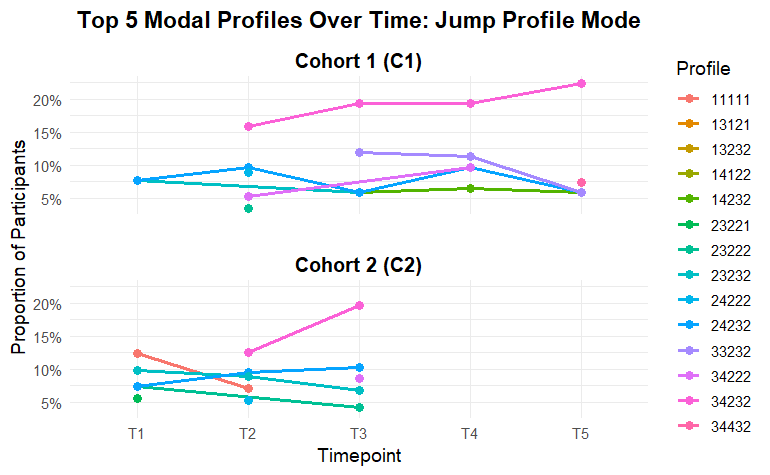

**Note:** Jump profile components are ordered as: Takeoff (Arm, Leg) + Landing (Arm, Foot, Shank).

| Cohort | Timepoint | 13121 | 13232 | 14122 | 23232 | 24232 | 34232 | 24222 | 34222 | 23222 | 33232 | 14232 | 34432 | 11111 | 23221 |
| --- | --- | --- | --- | --- | --- | --- | --- | --- | --- | --- | --- | --- | --- | --- | --- |
| C1 | T1 | 0.07692308 | 0.07692308 | 0.07692308 | 0.07692308 | 0.07692308 | 0.0000000 | 0.00000000 | 0.00000000 | 0.00000000 | 0.00000000 | 0.00000000 | 0.00000000 | 0.00000000 | 0.00000000 |
| C1 | T2 | 0.00000000 | 0.00000000 | 0.00000000 | 0.00000000 | 0.09734513 | 0.1592920 | 0.08849558 | 0.05309735 | 0.03539823 | 0.00000000 | 0.00000000 | 0.00000000 | 0.00000000 | 0.00000000 |
| C1 | T3 | 0.00000000 | 0.00000000 | 0.00000000 | 0.05970149 | 0.05970149 | 0.1940299 | 0.00000000 | 0.00000000 | 0.00000000 | 0.11940299 | 0.05970149 | 0.00000000 | 0.00000000 | 0.00000000 |
| C1 | T4 | 0.00000000 | 0.00000000 | 0.00000000 | 0.00000000 | 0.09677419 | 0.1935484 | 0.00000000 | 0.09677419 | 0.00000000 | 0.11290323 | 0.06451613 | 0.00000000 | 0.00000000 | 0.00000000 |
| C1 | T5 | 0.00000000 | 0.00000000 | 0.00000000 | 0.00000000 | 0.05970149 | 0.2238806 | 0.00000000 | 0.00000000 | 0.00000000 | 0.05970149 | 0.05970149 | 0.07462687 | 0.00000000 | 0.00000000 |
| C2 | T1 | 0.00000000 | 0.00000000 | 0.00000000 | 0.09876543 | 0.07407407 | 0.0000000 | 0.00000000 | 0.00000000 | 0.07407407 | 0.00000000 | 0.00000000 | 0.00000000 | 0.12345679 | 0.05555556 |
| C2 | T2 | 0.00000000 | 0.00000000 | 0.00000000 | 0.08928571 | 0.09523810 | 0.1250000 | 0.05357143 | 0.00000000 | 0.00000000 | 0.00000000 | 0.00000000 | 0.00000000 | 0.07142857 | 0.00000000 |
| C2 | T3 | 0.00000000 | 0.00000000 | 0.00000000 | 0.06837607 | 0.10256410 | 0.1965812 | 0.00000000 | 0.08547009 | 0.04273504 | 0.00000000 | 0.00000000 | 0.00000000 | 0.00000000 | 0.00000000 |

**Note:** Jump profile components are ordered as: Takeoff (Arm, Leg) + Landing (Arm, Foot, Shank).

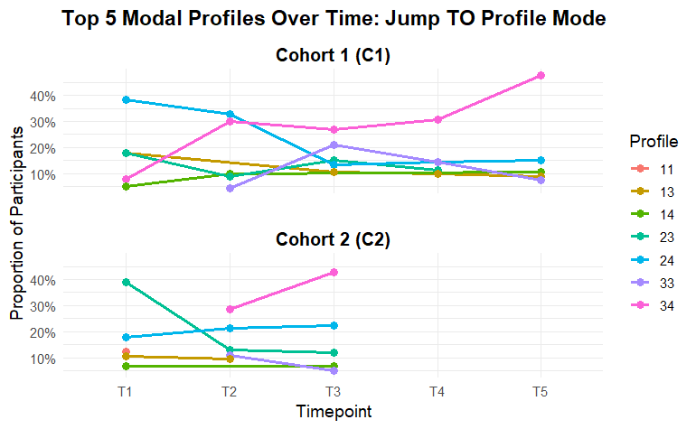

| Cohort | Timepoint | 24 | 13 | 23 | 34 | 14 | 33 | 11 |
| --- | --- | --- | --- | --- | --- | --- | --- | --- |
| C1 | T1 | 0.3846154 | 0.17948718 | 0.17948718 | 0.07692308 | 0.05128205 | 0.00000000 | 0.0000000 |
| C1 | T2 | 0.3274336 | 0.00000000 | 0.08849558 | 0.30088496 | 0.09734513 | 0.04424779 | 0.0000000 |
| C1 | T3 | 0.1343284 | 0.10447761 | 0.14925373 | 0.26865672 | 0.00000000 | 0.20895522 | 0.0000000 |
| C1 | T4 | 0.1451613 | 0.09677419 | 0.11290323 | 0.30645161 | 0.00000000 | 0.14516129 | 0.0000000 |
| C1 | T5 | 0.1492537 | 0.08955224 | 0.00000000 | 0.47761194 | 0.10447761 | 0.07462687 | 0.0000000 |
| C2 | T1 | 0.1790123 | 0.10493827 | 0.38888889 | 0.00000000 | 0.06790123 | 0.00000000 | 0.1234568 |
| C2 | T2 | 0.2142857 | 0.09523810 | 0.13095238 | 0.28571429 | 0.00000000 | 0.10714286 | 0.0000000 |
| C2 | T3 | 0.2222222 | 0.00000000 | 0.11965812 | 0.42735043 | 0.06837607 | 0.05128205 | 0.0000000 |

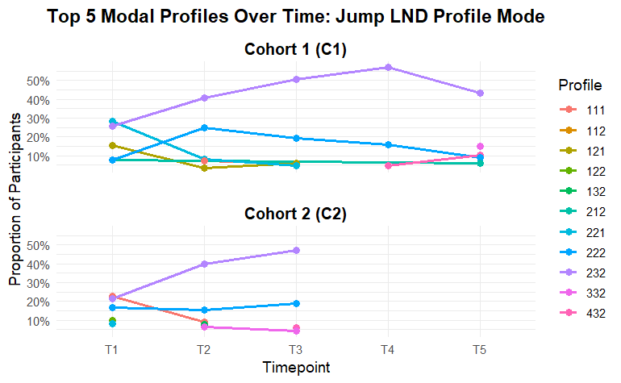

| Cohort | Timepoint | 221 | 232 | 121 | 212 | 222 | 111 | 112 | 132 | 432 | 332 | 122 |
| --- | --- | --- | --- | --- | --- | --- | --- | --- | --- | --- | --- | --- |
| C1 | T1 | 0.28205128 | 0.2564103 | 0.15384615 | 0.07692308 | 0.07692308 | 0.00000000 | 0.00000000 | 0.00000000 | 0.00000000 | 0.00000000 | 0.00000000 |
| C1 | T2 | 0.07964602 | 0.4070796 | 0.03539823 | 0.00000000 | 0.24778761 | 0.07079646 | 0.00000000 | 0.00000000 | 0.00000000 | 0.00000000 | 0.00000000 |
| C1 | T3 | 0.04477612 | 0.5074627 | 0.05970149 | 0.00000000 | 0.19402985 | 0.05970149 | 0.00000000 | 0.00000000 | 0.00000000 | 0.00000000 | 0.00000000 |
| C1 | T4 | 0.00000000 | 0.5714286 | 0.00000000 | 0.00000000 | 0.15873016 | 0.00000000 | 0.04761905 | 0.04761905 | 0.04761905 | 0.00000000 | 0.00000000 |
| C1 | T5 | 0.00000000 | 0.4328358 | 0.00000000 | 0.05970149 | 0.08955224 | 0.00000000 | 0.00000000 | 0.00000000 | 0.10447761 | 0.14925373 | 0.00000000 |
| C2 | T1 | 0.08024691 | 0.2160494 | 0.00000000 | 0.00000000 | 0.16666667 | 0.22839506 | 0.00000000 | 0.00000000 | 0.00000000 | 0.00000000 | 0.09876543 |
| C2 | T2 | 0.00000000 | 0.3988095 | 0.00000000 | 0.00000000 | 0.15476190 | 0.08928571 | 0.00000000 | 0.07738095 | 0.00000000 | 0.06547619 | 0.00000000 |
| C2 | T3 | 0.00000000 | 0.4700855 | 0.00000000 | 0.05982906 | 0.18803419 | 0.00000000 | 0.00000000 | 0.00000000 | 0.05982906 | 0.04273504 | 0.00000000 |